# 丸型、流線型、楕円型および角型管の引張、圧縮、曲げ、ねじり、および複合荷重における強度と設計

## 問題1

### ケース 1.

管サイズ: $1 - .049$ 丸管。  
$L = 24$ , $c = 1$ , 材質: 2024-T3  
破壊圧縮荷重を求めよ。

**解答:**  
Fig. C4.6の柱曲線は、使用されている式が（文献1）で現在指定されている式とわずかに異なっているため、やや安全側の値となっている。  
$L = 24$ を使用すると、 $1-049$ 管に対して破壊荷重 $2800 \text{ lb}$ が読み取れる。

第2の解法として、Fig. C4.3を使用する。
$$L' = \frac{L}{\sqrt{c}} = \frac{24}{\sqrt{1}} = 24$$

$$\frac{L'}{\rho} = \frac{24}{.3367} = 71.3$$

Fig. C4.3より、 $F_c = 20000$ を読み取る。
したがって、
$$P_a = F_c A = 20000 \times .1464 = 2930 \text{ lb}$$

この解答は式C4.9に代入することでも得られる。
$$F_c = 50600 - 431 \frac{L'}{\rho} = 50600 - 431 (71.3) = 19900$$

$$P_a = 19900 \times .1464 = 2920 \text{ lb}$$

柱は管壁の局部座屈または潰れ（crippling）によっても破壊する可能性があるため、潰れ応力 $F_{cc}$ を決定して、それが柱の一次曲げ破壊応力未満であるかどうかを確認する必要がある。

この管の厚さに対する外径の比は、 $D/t = 1.0/.049 = 20.40$ である。 $D/t$ の値はTable C4.3に示されている。

Fig. C4.3の右上隅にある小さな図を参照すると、 $D/t$ が $20.4$ のとき $F_{cc} = 47500 \text{ psi}$ であることがわかる。この応力は、柱の曲げ破壊応力である $20000$ よりも大きいため、臨界条件（クリティカル）ではない。

### ケース 2.

ケース1と同様だが、 $c = 1.5$ とし、材質を 6061-T6 アルミニウム合金に変更する。
$$L' = \frac{L}{\sqrt{c}} = \frac{24}{\sqrt{1.5}} = 19.7$$

$$\frac{L'}{\rho} = \frac{19.7}{.3367} = 58.5$$

Fig. C4.3より、 $F_c = 22500$
よって、
$$P_a = 22500 \times .1464 = 3300 \text{ lb}$$

$D/t = 20.4$ に対する $F_{cc}$ は Fig. C4.3 より $38500$ である（臨界ではない）。

### ケース 3.

ケース2と同様だが、材質をマグネシウム合金（ $F_{cy} = 10,000$ ）に変更する。

$\frac{L'}{\rho} = 58.5$ に対し、Fig. C4.4のより低い曲線を使用すると、 $F_c = 7600$ が読み取れる。
したがって、
$$P_a = F_c A = 7600 \times .1464 = 1110 \text{ lb}$$

## C4.15 流線型管の強度

丸管が気流にさらされると、空気抵抗は流線型にした場合の約15倍大きくなる。そのため、部材が気流にさらされる場所には流線型管が使用される。

流線型管は丸管を引き抜いて成形される。流線型管を指定する際は、元の丸管のサイズが使用され、その後に扁平率（fineness ratio）が示される。扁平率は比 $L/D$ であり、その寸法は Fig. C4.8 に示されている。最も一般的に使用される扁平率は 2.5:1 である。Table C4.6 は、扁平率が 2.5:1 の流線型管の断面特性を示している。Figs. C4.9 および C4.10 は、柱破壊応力 $F_c$ および局部潰れ応力 $F_{cc}$ を求めるための曲線を示している。

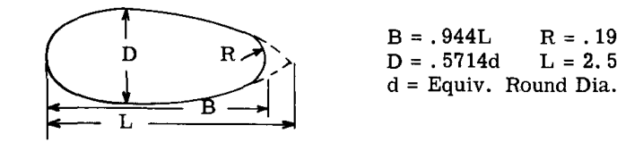

Fig. C4.8

### 問題 1. ケース 1.

元となる丸管サイズが $2-1/2 - .065$ の流線型管があり、扁平率は 2.5:1 である。長さ $L$ は $30 \text{ in.}$ である。 $c = 1$ と仮定する。材質は合金鋼（ $F_{ty} = 75000$ ）である。この部材が負担できる許容圧縮荷重を求めよ。

**解答:**
Table C4.6より、 $2-1/2 - .065$ サイズの以下の断面特性を得る。
断面積 $(A) = .4972$ , $\rho$ (長軸) $= .5137 \text{ in.}$
したがって、
$$L' = \frac{L}{\sqrt{c}} = \frac{30}{\sqrt{1}} = 30$$

および
$$\frac{L'}{\rho} = \frac{30}{.5137} = 58.5$$

### ケース 2.

ケース1と同様だが、材質を 2024-T6 アルミニウム合金に変更する。

この材質については、Fig. C4.10 を使用する。
$\frac{L'}{\rho} = 58.5$ に対して $F_c = 26000 \text{ psi}$ を読み取る。
$D/t = 38.5$ に対して $F_{cc} = 37500$ を読み取る（臨界ではない）。
したがって、
$$P_a = 26000 \times .4972 = 12900 \text{ lb}$$

## C4.16 楕円型および角型管の圧縮強度

Table C4.8 および Table C4.7 は、それぞれ角型および楕円型管の断面特性を示している。これら成形された管の設計において、一次柱強度は Figs. C4.9 および C4.10 の曲線を用いて求めることができる。

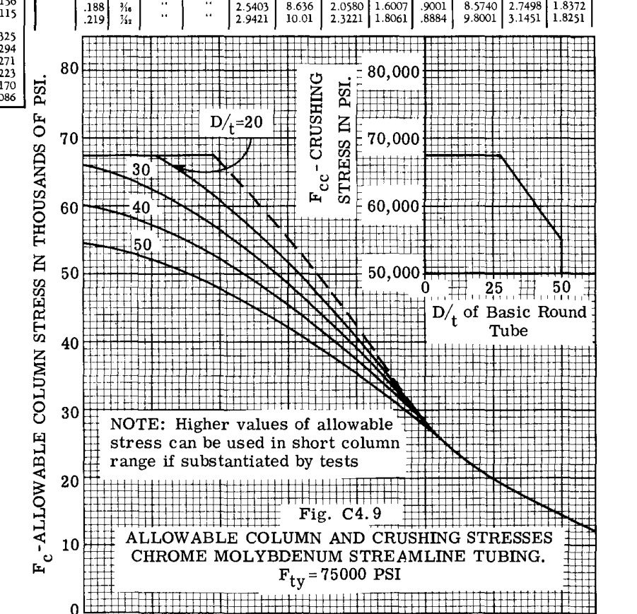

Fig. C4.9

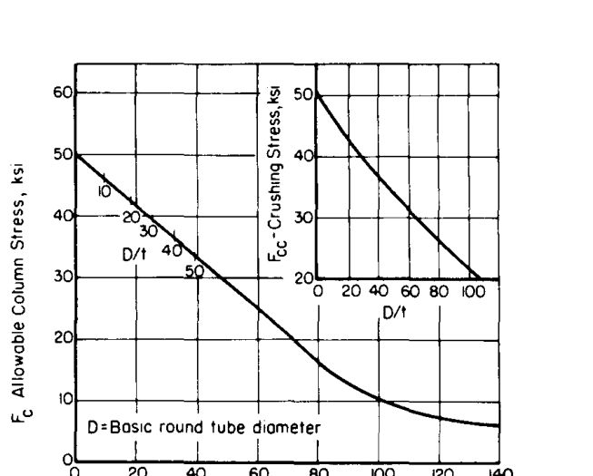

Fig. C4.10

楕円型管の潰れ応力 $F_{cc}$ は、安全側に Figs. C4.9 および C4.10 に示されている流線型管の値と同じとして扱うことができる。角型管の場合、局部潰れ応力 $F_{cc}$ は平板の座屈（crippling）応力として扱うことができる。この応力については、さまざまな幅、厚さ、および境界支持条件を持つ平板の座屈および潰れ応力を扱った章を参照されたい。

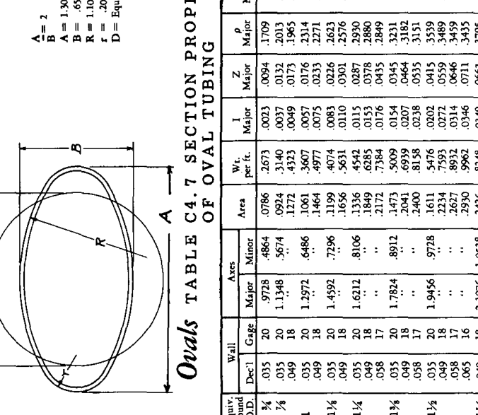

Table C4.7

# 丸管の極限曲げ強度

## C4.17 破断係数応力を求めるための図表

第C3章では、純曲げにおける断面の極限降伏応力および破壊応力を決定するための理論と方法を扱った。そこでは、よく知られた梁の公式 $M = F_b I/c$ に代入したときに、破壊を引き起こす曲げモーメントの値を与える仮想的な応力 $F_b$ （破断係数）を求めることが主眼であった。

丸管の曲げにおける破断係数応力（ $F_b$ ）を求めるためにも、第C3章で使用したものと同様の手順を使用することができる。しかし、丸管は長年にわたり標準的かつ利用可能な構造部材であったため、管に関する多くの試験が行われており、その結果、丸管の曲げにおける破断係数（ $F_b$ ）を求めるための完全な設計曲線が利用可能である。Figs. C4.11 から C4.14 は、合金鋼、アルミニウム合金、マグネシウム合金、およびチタン合金から製造された丸管の曲げにおける破断係数を求めるための曲線を示している。

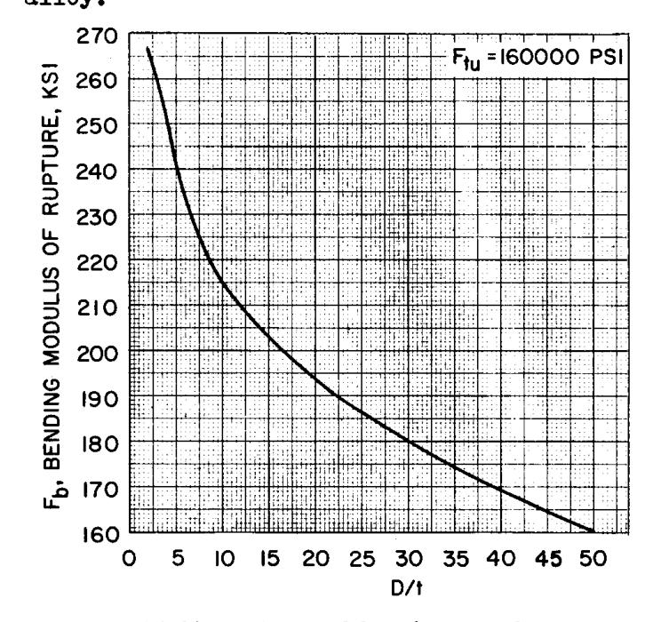

Fig. C4.14

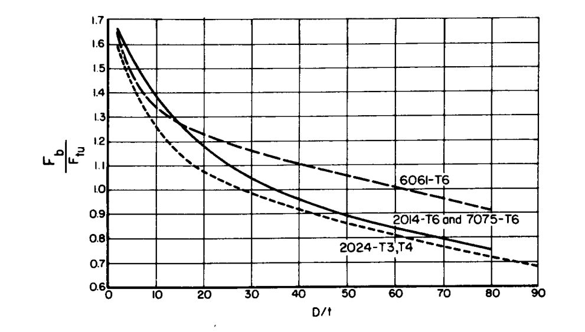

Fig. C4.12

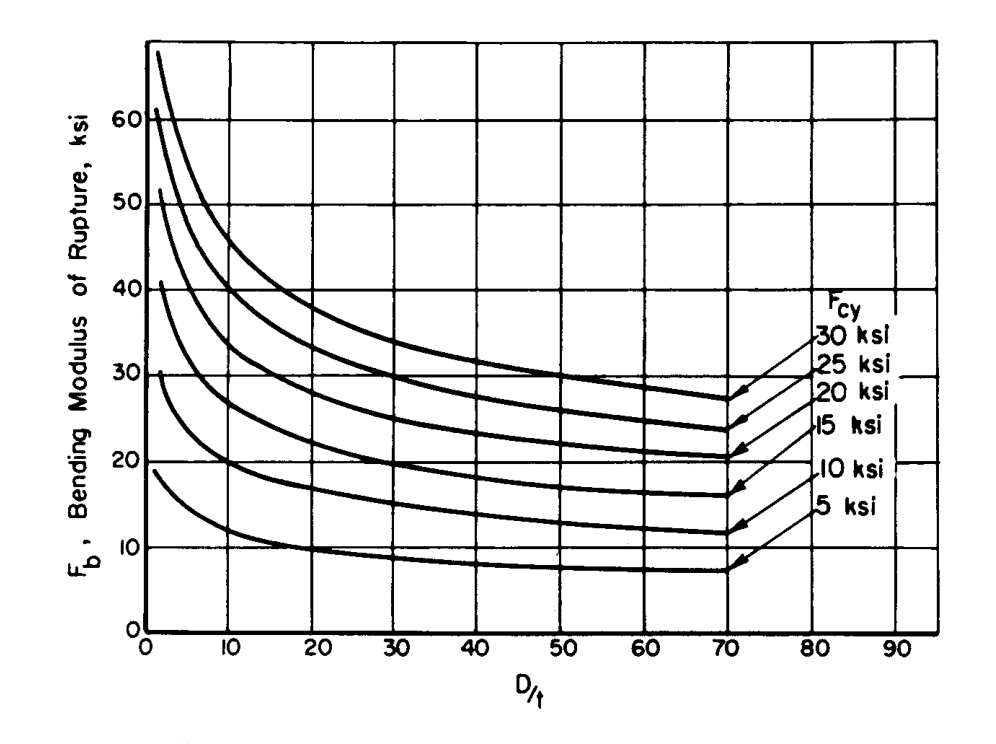

Fig. C4.13

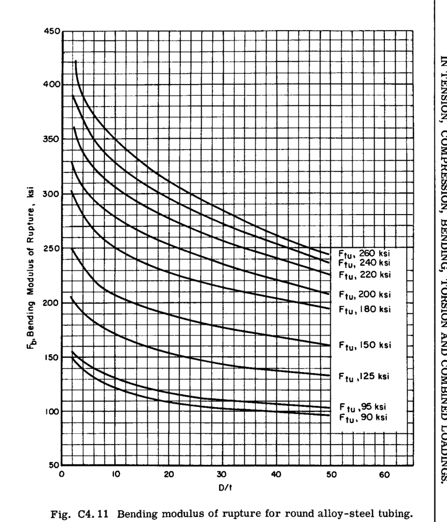

Fig. C4.11

## C4.18 管の曲げ強度に関する問題

### 問題 1

$1-1/4 - .058$ の丸管が、両端を単純支持された梁として使用されている。梁のスパン（長さ）は 24 インチである。1インチあたり $w$ ポンドの一様分布荷重を支持している。管が以下の材料で作られている場合、曲げによって破壊に至る $w$ の値を求めよ。 - 合金鋼: $F_{tu} = 95000$ - 6061-T6 アルミニウム合金 - 6AL-4V チタン合金

**解答:**
最大曲げモーメントはスパンの中央で発生し、その値は次のようになる。
$$M = \frac{w L^2}{8} = \frac{w \times 24^2}{8} = 72w \text{ in. lb}$$

管の断面特性は、Table C4.3より $D/t = 21.55$ および $I/y = .06187$ である。

破断係数 $F_b$ を含む梁の公式は $M = F_b I/y$ である。 $M$ に $72w$ を代入すると、以下を得る。
$$w = \frac{F_b I}{72y}$$

合金鋼（ $F_{tu} = 95000$ ）を考える。
Fig. C4.11より、 $D/t = 21.55$ に対して $F_b = 117000$ を読み取る。
したがって、
$$w = \frac{117000 \times .06187}{72} = 100.2 \text{ lb/in.}$$

### 問題 2

両端が単純支持されたスパン 30 インチの梁がある。設計極限荷重は、それぞれ $2000 \text{ lbs}$ の2つの等しい荷重から構成されている。梁は対称に荷重が載荷されており、各荷重は端部から 12 インチの位置にある。

以下の材料で作られた場合について、最も軽量な丸管を選定せよ。  
(1) 合金鋼: $F_{tu} = 220000$  
(2) 7075-T6 アルミニウム合金  
得られた管の重量を比較せよ。

**解答:**
最大曲げモーメントは荷重間で一定であり、その値は次のようになる。
$$M = 2000 \times 12 = 24000 \text{ in. lb}$$

許容または破壊曲げ応力は $D/t$ の関数であり、管のサイズが未知であるため、設計または解決手順は試行錯誤（トライアル・アンド・エラー）による。

破断係数曲線の観察から、 $D/t$ が増加すると $F_b$ が減少することがわかる。これは、曲げ破壊が局所的な破壊であり、肉厚が薄く直径が大きいほど、座屈または潰れ応力が低下するためである。しかし、 $D/t$ の値が大きくなるほど、管の断面係数 $I/y$ が大きくなり、曲げ抵抗が増加することを意味する。したがって、曲げ強度に影響を与える2つの相反する効果が存在する。

検討のために管のサイズを予測する方法は多くある。この例題では、 $D/t$ について2つの値を仮定し、計算される $I/y$ がどのようになるかを確認する。2つの $D/t$ の値を 45 および 25 と仮定する。

材質を合金鋼（ $F_{tu} = 220000$ ）とする。
Fig. C4.11より、 $D/t = 45$ に対して $F_b = 232000$ 。
したがって、
$$I/y = M/F_b = 24000/232000 = .103$$

$D/t = 25$ に対して $F_b = 266000$ 。
したがって、
$$I/y = 24000/266000 = .089$$

したがって、Table C4.3を参照して、 $I/y$ の値が .089 から .103 の範囲に近い管を選択し、その後、それらの真の曲げ強度を求める。Table Aは、Fig. C4.11を用いた選定および必要な計算を示している。

#### Table A

[output not shown]

正の安全余裕（M.S.）を持つ、入手可能な最も軽量な管は $1-3/4 - .049$ であり、長さ 30 インチに対する重量は次のようになる。
$$30 \times .2618 \times 0.283 = 2.22 \text{ lbs}$$

次に、材質が 7075-T6 アルミニウム合金（ $F_{tu} = 77000$ ）で作られた管を考える。

Fig. C4.12より、
$D/t = 60$ に対して $F_b/F_{tu} = .84$ 、したがって $F_b = .84 \times 77000 = 64700$ 。
$$I/y = M/F_b = 24000/64700 = .37$$

$D/t = 30$ に対して $F_b/F_{tu} = 1.045$ 、したがって $F_b = 1.045 \times 77000 = 80500$ 。
$$I/y = 24000/80500 = .30$$

したがって、Table C4.3から $I/y$ の値が .30 から .37 の範囲にある管を選択する。

$2-3/4 - .058$ を試す。
$I/y = .3233$ , $D/t = 47.4$ 。
Fig. C4.12より、 $F_b/F_{tu} = 0.90$ 。したがって $F_b = .90 \times 77000 = 69300 \text{ psi}$ 。
このとき、
$$M_a = F_b I/y = 69300 \times .3233 = 22400$$

これは設計曲げモーメントの 24000 よりも小さいため、この管では強度が不足している。

$3 - .058$ を試す。
$I/y = .3868$ , $D/t = 51.7$ 。
$F_b/F_{tu} = .885$ , $F_b = .885 \times 77000 = 68000$ 。
$$M_a = F_b I/y = 68000 \times .3868 = 26300$$

$$\text{M.S.} = (26300/24000) - 1 = .09$$

Table C4.3の他の管を検討すると、これよりも軽量な管は存在しないことがわかる。

学生は、Figs. C4.14 および C4.13 をそれぞれ使用して、最も軽量なチタン管および最も軽量なマグネシウム管を計算し、上記で得られた鋼およびアルミニウムとの重量結果を比較されたい。

# 丸管の極限ねじり強度

## C4.19 ねじり破断係数

第A6章のArticle A6.2において、円形断面のねじり公式 $f_s = Tr/J$ が導出された。この式は、丸棒または管の横断面における最大剪断応力が材料の比例限度を超えないこと、または応力変化が Fig. C4.15 に示すように線形であることを前提としており、この状況は飛行状態の制限荷重（リミット荷重）下で存在する。延性材料で作られた丸棒がねじりによって破壊する前に、剪断応力は非弾性または塑性領域に入り、その内部剪断応力分布は Fig. C4.16 に示すものと同様になる。

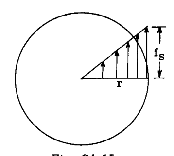

Fig. C4.15

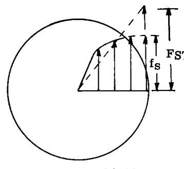

Fig. C4.16

剪断応力-ひずみ曲線は、引張応力-ひずみ曲線と形状が類似しており、縦座標の約0.6倍に等しい。したがって、極限内部ねじり抵抗モーメントを求めるために、断面積を多数の円形要素に分割することができる。Fig. C4.16の応力曲線から、円形要素の中点における応力を求めることができる。要素の面積にこの応力と要素の中心軸からの距離を乗じることで発生するモーメントが得られ、すべての円形要素の剪断力によるモーメントを足し合わせることで、全許容または極限内部ねじり抵抗モーメント $T_a$ が得られる。

このモーメント $T_a$ をねじり公式で使用する場合、Fig. C4.16の実際の応力曲線を、実際の応力曲線と同じ内部抵抗モーメントを生み出す最大値 $F_{st}$ を持つ三角形の応力曲線に置き換える必要がある。したがって、
$$T_a = F_{st} \frac{J}{r} \quad \text{または} \quad F_{st} = T_a
\frac{r}{J} \quad \cdots \text{(C4.10)}$$

$F_{st}$ はねじり破断係数応力と呼ばれる。これは仮想的な応力であり、材料の極限剪断応力よりも高い。ねじりを受ける管は、通常、非弾性もしくは塑性不安定、または $D/t$ 比が大きい場合には弾性不安定によって破壊する。信頼できる $F_{st}$ の値を得るためには、通常、試験に依存する。丸管または丸棒は最も効率的で入手しやすい形状であるため、長年にわたり多くの試験が行われており、飛行体の一般的な材料で作られた丸管の設計曲線が容易に利用可能である。

## C4.20 ねじり破断係数曲線

Figs. C4.17 から C4.24 は、 $F_{tu} = 95000$ から $260,000 \text{ psi}$ までの鋼合金に対するねじり破断係数応力 $F_{st}$ を求めるための曲線を示している。ねじり強度は、管の $D/t$ および $L/D$ 値の影響を受けることに注意されたい。Figs. C4.25 から C4.30 は各種アルミニウム合金の曲線を示し、Fig. C4.31 は1つのマグネシウム合金の情報を示している。これらの曲線はすべて（文献1）から引用されたものである。

これらの曲線は、LeeおよびAdesによる理論的研究（文献2を参照）に基づいており、実験結果と良好に一致することが確認されている。

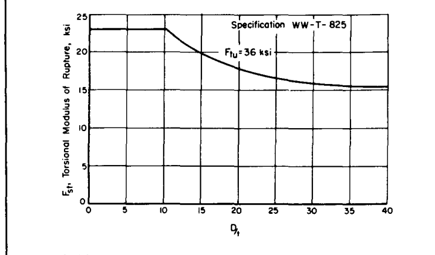

Fig. C4.31

## C4.21 ねじり破断係数曲線の使用例題

### 問題 1

$1-5/8 - .065$ の丸管の長さが 16.25 インチである。この管が以下の材料で作られている場合、どのような極限ねじりモーメントを発生させることができるか。  
(1) 合金鋼: $F_{tu} = 95000$  
(2) アルミニウム合金: 2024-T3

**解答:**
$D/t = 25$ 。
$$\frac{J}{r} = 2 \left( \frac{I}{y} \right) = 2 \times 0.11948 = 0.2390$$

$$\frac{L}{D} = \frac{16.25}{1.625} = 10$$

合金鋼（ $F_{tu} = 95000$ ）の場合、Fig. C4.17 を使用し、 $D/t = 25$ および $L/D = 10$ に対して $\frac{F_{st}}{1000} = 47.3$ を読み取る。したがって、 $F_{st} = 47300$ 。
$$T_a = F_{st} \frac{J}{r} = 47300 \times 0.2390 = 11300 \text{ in. lb}$$

2024-T3 アルミニウム合金の場合、Fig. C4.26 を参照し、 $F_{st} = 29000$ を読み取る。
したがって、
$$T_a = F_{st} \frac{J}{r} = 29000 \times 0.2390 = 6930 \text{ in. lb}$$

### 問題 2

長さ 10 インチの丸管が、極限ねじりモーメント $7000 \text{ in. lb}$ を伝達する必要がある。アルミニウム合金 2024-T4、および合金鋼（ $F_{tu} = 200,000$ ）で作られた場合について、最も軽量な管を選定し、それぞれの結果重量を比較せよ。

**解答:**  
破断係数は $D/t$ および $L/D$ に依存し、管のサイズが未知であるため、試行錯誤（トライアル・アンド・チェック）のアプローチを使用する。設計計算は、以下のように表形式で便利に行うことができる。

#### アルミニウム合金 2024-T4 (Fig. C4.27)

| トライアル管サイズ | 断面積 | $D/t$ | $J/r$ | $L/D$ | $F_{st}$ | $T_a = F_{st} J/r$ | $\text{M.S.} = \frac{T_a}{T} - 1$ |
| --- | --- | --- | --- | --- | --- | --- | --- |
| $1-1/2 - .065$ | $.2930$ | $23.05$ | $.2016$ | $6.7$ | $30000$ | $6050$ | $-.14$ |
| $1-3/4 - .058$ | $.3083$ | $30.20$ | $.2525$ | $5.7$ | $28000$ | $7060$ | $.01$ |
| $1-7/8 - .049$ | $.2811$ | $38.25$ | $.2500$ | $5.3$ | $26000$ | $6500$ | $-.07$ |
| $2.0 - .049$ | $.3003$ | $40.30$ | $.2860$ | $5.0$ | $26000$ | $7440$ | $.06$ |

#### 合金鋼 $F_{tu} = 200,000$ (Fig. C4.21)

| トライアル管サイズ | 断面積 | $D/t$ | $J/r$ | $L/D$ | $F_{st}$ | $T_a = F_{st} J/r$ | $\text{M.S.} = \frac{T_a}{T} - 1$ |
| --- | --- | --- | --- | --- | --- | --- | --- |
| $1 - .035$ | $.1061$ | $28.56$ | $.0495$ | $10$ | $98000$ | $4850$ | $-.31$ |
| $1 - .049$ | $.1461$ | $20.40$ | $.0664$ | $10$ | $106000$ | $7050$ | $.01$ |
| $1-1/4 - .035$ | $.1336$ | $35.70$ | $.0790$ | $8$ | $94000$ | $7430$ | $.06$ |